# Introduction to data science - Ch8

# Evaluating models

Evaluating a model is done during the training stage. To goal is to quantitatively determine if the model produces interesting results with the training data.

We calculate summary metrics (scores) helping us to evaluate the model.

## The null model

Also called the ideal model. It is the baseline. Our model has to perform better than the null model. Otherwise our model will be interesting to no one. It can be :

- a constant outcome (a model returning same result every time)
- an independent outcome (not related with )

For a categorical problem : the null model might be the most popular category.

For a numerical problem (scoring) : the null model could be the average value.

The following metrics are used to evaluate classification model performance :

- accuracy
- precision
- recall

Let us study them with an example from the *Spambase* [dataset](http://mng.bz/e8Rh). It is a database of metrics derived of emails. Our task is to create a spam filter through logistic regression.

Let us first read the dataset into a variable :

```r
spamD <- read.table("https://github.com/scizmeli/datascience_class_helper_files/raw/master/spamD.tsv", header=T, sep="\t")

dim(spamD)
head(spamD)
```

[output not shown]

## Exercise 4.1

What can you say about this data?

```r
#Set train and test samples
spamTrain <- subset(spamD,spamD$rgroup>=10)
spamTest <- subset(spamD,spamD$rgroup<10)

#Select columns to be included in the modeling
spamVars <- setdiff(colnames(spamD),list('rgroup','spam'))

#Our formula will be long. Let us create it from a string
spamFormula <- as.formula(paste('spam=="spam"', paste(spamVars,collapse=' + '),sep=' ~ '))
spamFormula
```

Consult the base R cheatsheet for more info about formulas for modeling in R :

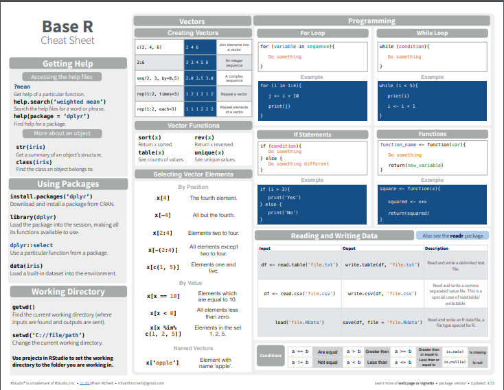

You can download the pdf version [here](https://github.com/scizmeli/datascience_class_helper_files/raw/master/base-r-cheatsheet.pdf). Now that we have our data and model formula set correctly, let us perform logistic regression as a method of classification :

```r
spamModel <- glm(spamFormula,family=binomial(link='logit'), data=spamTrain)
summary(spamModel)
```

```r
# Now compute predictions using the training and test data
spamTrain$pred <- predict(spamModel,newdata=spamTrain, type='response')
spamTest$pred <- predict(spamModel,newdata=spamTest, type='response')
```

A sample of the results :

```r
sample <- spamTest[c(7,35,224,327),c('spam','pred')]
print(sample)
```

[output not shown]

Preparing the confusion matrix :

```r
cM <- table(truth=spamTest$spam,prediction=spamTest$pred>0.5)
print(cM)
```

[output not shown]

Explanation of the confusion matrix :

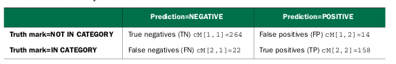

The confusion matrix provides a lot of useful information. Let’s get started with accuracy:

### Accuracy

Accuracy of classification is simply the number of items categorized correctly divided by the total number of items. In this case we achieved 92% accuracy.

### Precision & Recall

Precision is the fraction of the items correctly classified to the total class size. So precision is TP/(TP+FP), about 0.92 in our spam filter case. It is coincidence that accuracy and precision are close to each other.

Recall is TP/(TP+FN), i.e. the fraction of the things that are in the class are detected by the classifier. In our case it is 88%.

Precision answers the question : "how often can our classifier is able to correctly attribute to the right class. As an example, the Akismet spam filter has a precision of 99.99%. In a spam detection application, precision is more important than recall.

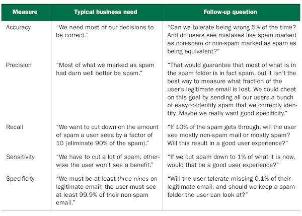

## Evaluating probabilities

- The second way to evaluate the probabilty models is to look at the probabilities they compute
- These metrics are very performant and technical
- But they difficult to translate to easly understandable business goals -> not necessarily to be shared with clients The double-density plot allows us to check the probability tresholds : We want in-class predictions to be high, off-class predictions to be low :

```r
library(ggplot2)
ggplot(data=spamTest) +
    geom_density(aes(x=pred,color=spam,linetype=spam))
```

[output not shown]

## Keep in mind

- If your input data is unbalanced, accuracy is not a good indicator
- You can trade off between precision and recall by playing with the 0.5 score threshold
- Also look at other evaluators : ROCR, log-likelihood, deviance, AIC and entropy :)

## Evaluating scoring models

### Residuals

Residuals is the first thing to look at to evaluate the performance of a regression (scoring) model. Let us try to fit a linear model into a 2nd degree polynomial and plot the residuals for a **visual** analysis :

```r
d <- data.frame(y=(1:10)^2,x=1:10)
model <- lm(y~x,data=d)
d$prediction <- predict(model,newdata=d)
library('ggplot2')
ggplot(data=d) +
geom_point(aes(x=x,y=y)) +
geom_line(aes(x=x,y=prediction),color='blue') +
geom_segment(aes(x=x,y=prediction,yend=y,xend=x))
```

[output not shown]

### Root mean square error RMSE

# metrelerle olcum yapıyorsak metreyle rmse degeri hatasını verebiliriz.

- Shows goodness-to-fit # kusursuz dogruya ne kadar yakınız onu gösterir
- Same units as *y*
- Manu algorithms to minimise RMSE

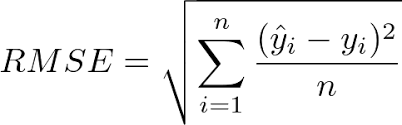

### R-squared R^2

# 1 ideal korelasyon

# x ve y arasındaki iliskinin kuvvetini bize verir

# outlier degerlerden cok etkilenir.

- R^2 is the coefficient of determination
- It is dimensionless and is within range [0,1]
- Tells us about the strength of the relationship between *x* and *y*
- It tells **how much variations in y is explained by x**
- In R, you can extract the value of R2 using : `summary(model_object)$r.squared`

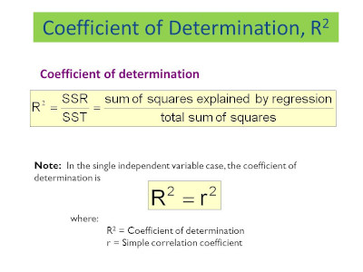

## Evaluating clustering models

- Evaluating clustering models are difficult because they are nonsupervised
- The first evaluation is the number of detected clusters
- We also look at how many items are in the cluster -> avoid too big and too small clusters
- We want clusters to be as compact as possible (see below distance metrics)

Let’s create random points to be clustered :

```r
# Let's create random points to be clustered
set.seed(32297)
d <- data.frame(x=runif(100),y=runif(100))
clus <- kmeans(d,centers=5)
class(clus)
d$cluster <- clus$cluster
```

And then plot clustering results :

```r
library('ggplot2'); library('grDevices')
h <- do.call(rbind, lapply(unique(clus$cluster),function(c) {
    f <- subset(d,cluster==c); f[chull(f),]
}))

ggplot() +
    geom_text(data=d,aes(label=cluster,x=x,y=y,
    color=cluster),size=3) +
    geom_polygon(data=h,aes(x=x,y=y,group=cluster,fill=as.factor(cluster)),alpha=0.4,linetype=0) +
    theme(legend.position = "none")
```

[output not shown]

We can check number of items in each cluster with the function *table()* :

```r
table(d$cluster)# her sınıfta kac tane data var
tail(d$cluster)
```

Calculating the mean distance from points in one cluster to points in another :

```r
# kümeler arası benzerligi ve kümeler ici benzerligi hesaplayan kod blogu
library('reshape2')

n <- dim(d)[1]

pairs <- data.frame(
        ca = as.vector(outer(1:n,1:n,function(a,b) d[a,'cluster'])),
        cb = as.vector(outer(1:n,1:n,function(a,b) d[b,'cluster'])),
        dist = as.vector(outer(1:n,1:n,function(a,b)
                sqrt((d[a,'x']-d[b,'x'])^2 + (d[a,'y']-d[b,'y'])^2)))
        )

dcast(pairs,ca~cb,value.var='dist',mean)


# diagonal olması kendi arasındaki degiskenligi 1.satır 1.sütun ,2.satır 2.sütun gibi ----> 1.kümeyle 1.küme
#1. satır 3. sütun demek ise 1. kümeyle 3. küme arasındaki degiskenligin sayısal karsılıgını verir
```

[output not shown]